# Prediction Assignment Writeup

Bjoern

January 15, 2017

## Overview & Objective

The goal was to predict whether a person is performing barbell lifts correctly or incorrectly (in 5 different ways). Data from accelerometers on the belt, forearm, arm, and dumbell from 6 study participants were available, who performed barbell lifts under supervision either correctly or in one out of 5 incorrect ways. In the training data, the “classe” variable indicates the exercise quality type. More information on these data is available at http://groupware.les.inf.puc-rio.br/har (see the section on the Weight Lifting Exercise Dataset).

The task was to build a prediction/classification model, create a report how the model was built, how cross validation was used, and what the expected out of sample error is. Finally, the model was used to predict 20 different test cases.

## Reading data sets

First the training and testing data was read in and a first overview was generated.

```r
training = read.csv("pml-training.csv")
training[training==""]=NA
testing = read.csv("pml-testing.csv")
```

The training data set has 19622 entries and the testing set has 20 entries.

First, we look at the summary of the training set:

```
##        X            user_name    raw_timestamp_part_1 raw_timestamp_part_2
##  Min.   :    1   adelmo  :3892   Min.   :1.322e+09    Min.   :   294
##  1st Qu.: 4906   carlitos:3112   1st Qu.:1.323e+09    1st Qu.:252912
##  Median : 9812   charles :3536   Median :1.323e+09    Median :496380
##  Mean   : 9812   eurico  :3070   Mean   :1.323e+09    Mean   :500656
##  3rd Qu.:14717   jeremy  :3402   3rd Qu.:1.323e+09    3rd Qu.:751891
##  Max.   :19622   pedro   :2610   Max.   :1.323e+09    Max.   :998801
##
##           cvtd_timestamp  new_window    num_window      roll_belt
##  28/11/2011 14:14: 1498   no :19216   Min.   :  1.0   Min.   :-28.90
##  05/12/2011 11:24: 1497   yes:  406   1st Qu.:222.0   1st Qu.:  1.10
##  30/11/2011 17:11: 1440               Median :424.0   Median :113.00
##  05/12/2011 11:25: 1425               Mean   :430.6   Mean   : 64.41
##  02/12/2011 14:57: 1380               3rd Qu.:644.0   3rd Qu.:123.00
##  02/12/2011 13:34: 1375               Max.   :864.0   Max.   :162.00
##  (Other)         :11007
##    pitch_belt          yaw_belt       total_accel_belt kurtosis_roll_belt
##  Min.   :-55.8000   Min.   :-180.00   Min.   : 0.00    #DIV/0!  :   10
##  1st Qu.:  1.7600   1st Qu.: -88.30   1st Qu.: 3.00    -1.908453:    2
##  Median :  5.2800   Median : -13.00   Median :17.00    -0.016850:    1
##  Mean   :  0.3053   Mean   : -11.21   Mean   :11.31    -0.021024:    1
##  3rd Qu.: 14.9000   3rd Qu.:  12.90   3rd Qu.:18.00    -0.025513:    1
##  Max.   : 60.3000   Max.   : 179.00   Max.   :29.00    (Other)  :  391
##                                                        NA's     :19216
##  kurtosis_picth_belt kurtosis_yaw_belt skewness_roll_belt
##  #DIV/0!  :   32            :    0     #DIV/0!  :    9
##  47.000000:    4     #DIV/0!:  406     0.000000 :    4
##  -0.150950:    3     NA's   :19216     0.422463 :    2
##  -0.684748:    3                       -0.003095:    1
##  -1.750749:    3                       -0.010002:    1
##  (Other)  :  361                       (Other)  :  389
##  NA's     :19216                       NA's     :19216
##  skewness_roll_belt.1 skewness_yaw_belt max_roll_belt     max_picth_belt
##  #DIV/0!  :   32             :    0     Min.   :-94.300   Min.   : 3.00
##  0.000000 :    4      #DIV/0!:  406     1st Qu.:-88.000   1st Qu.: 5.00
##  -2.156553:    3      NA's   :19216     Median : -5.100   Median :18.00
##  -3.072669:    3                        Mean   : -6.667   Mean   :12.92
##  -6.324555:    3                        3rd Qu.: 18.500   3rd Qu.:19.00
##  (Other)  :  361                        Max.   :180.000   Max.   :30.00
##  NA's     :19216                        NA's   :19216     NA's   :19216
```

[output cut: 313 more lines]

```
##  Min.   :-446.00   Min.   :-1280.0   Min.   :-896.0   Min.   :-973.0
##  1st Qu.:-182.00   1st Qu.: -616.0   1st Qu.:   2.0   1st Qu.: 191.0
##  Median : -39.00   Median : -378.0   Median : 591.0   Median : 511.0
##  Mean   : -55.29   Mean   : -312.6   Mean   : 380.1   Mean   : 393.6
##  3rd Qu.:  26.00   3rd Qu.:  -73.0   3rd Qu.: 737.0   3rd Qu.: 653.0
##  Max.   : 291.00   Max.   :  672.0   Max.   :1480.0   Max.   :1090.0
##
##  classe
##  A:5580
##  B:3797
##  C:3422
##  D:3216
##  E:3607
##
##
```

Note, that several predicators are mostly NA (i.e., missing values). Thus, we calculate the NA ratios:

```r
na_ratio = apply(training,2,function(x) sum(is.na(x))/length(x))
```

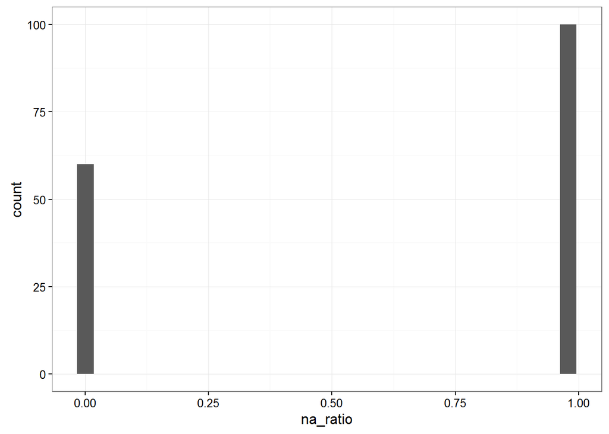

Figure. Histogram of NA ratio.

```r
dat = data.frame(na_ratio = na_ratio)
p = ggplot(aes(x = na_ratio), data = dat)
p = p + geom_histogram()
p = p + theme_bw()
print(p)
```

We only keep the predictors with an na_ratio<0.1.

```r
tokeep = colnames(training)[na_ratio < 0.1]
training = training[,colnames(training) %in% tokeep]
training = training
testing = testing[,colnames(testing) %in% tokeep]
```

## Partition data for for estimation of the out of sample error

```r
set.seed(325)
inTrain = createDataPartition(training$classe, p = 3/4)[[1]]
dat_train = training[ inTrain,]
dat_test = training[-inTrain,]
```

The first seven columns of the data (X,user_name,raw_timestamp_part_1,raw_timestamp_part_2,cvtd_timestamp,new_window,num_window) are meta information and are not considered in the classification models.

```r
dat_train = dat_train[,-c(1:7)]
```

## Train and evaluate classification models

Three different classification models were trained using 10-fold cross-validation for (tuning) parameter selection: a random forest model (rf), a boosted tree model (gbm), and a linear discriminant analysis model (lda):

```r
set.seed(343)
train_control <- trainControl(method="cv", number=10)
fit.rf = train(classe~.,data = dat_train, trControl = train_control, method = "rf")
fit.gbm = train(classe~.,data = dat_train, trControl = train_control, method = "gbm")
fit.lda = train(classe~.,data = dat_train, trControl = train_control, method = "lda")
```

Based on the cross-validation results (i.e., largest estimated accuracy), the following tuning parameters were selected for the three models: mtry = 2 for the random forrest model; n.trees = 150, interaction.depth = 3, shrinkage = 0.1, and n.minobsinnode = 10 for the boosted tree model (gbm); and no tunining parameter had to be selected for the lda model.

To estimate the out of sample error, each model was used to predict the “classe” for the testing set (from the data set partition):

```r
pred.rf = predict(fit.rf, newdata = dat_test)
cm.rf = confusionMatrix(pred.rf, dat_test$classe)
print(cm.rf)
```

```
## Confusion Matrix and Statistics
##
##           Reference
## Prediction    A    B    C    D    E
##          A 1395    2    0    0    0
##          B    0  945    8    0    0
##          C    0    2  846   11    0
##          D    0    0    1  792    1
##          E    0    0    0    1  900
##
## Overall Statistics
##
##                Accuracy : 0.9947
##                  95% CI : (0.9922, 0.9965)
##     No Information Rate : 0.2845
##     P-Value [Acc > NIR] : < 2.2e-16
##
##                   Kappa : 0.9933
##  Mcnemar's Test P-Value : NA
##
## Statistics by Class:
##
##                      Class: A Class: B Class: C Class: D Class: E
## Sensitivity            1.0000   0.9958   0.9895   0.9851   0.9989
## Specificity            0.9994   0.9980   0.9968   0.9995   0.9998
## Pos Pred Value         0.9986   0.9916   0.9849   0.9975   0.9989
## Neg Pred Value         1.0000   0.9990   0.9978   0.9971   0.9998
## Prevalence             0.2845   0.1935   0.1743   0.1639   0.1837
## Detection Rate         0.2845   0.1927   0.1725   0.1615   0.1835
## Detection Prevalence   0.2849   0.1943   0.1752   0.1619   0.1837
## Balanced Accuracy      0.9997   0.9969   0.9931   0.9923   0.9993
```

```r
pred.gbm = predict(fit.gbm, newdata = dat_test)
cm.gbm = confusionMatrix(pred.gbm, dat_test$classe)
print(cm.gbm)
```

```
## Confusion Matrix and Statistics
##
##           Reference
## Prediction    A    B    C    D    E
##          A 1377   26    0    0    1
##          B   14  906   30    2    7
##          C    2   16  813   22    4
##          D    2    1   12  773    8
##          E    0    0    0    7  881
##
## Overall Statistics
##
##                Accuracy : 0.9686
##                  95% CI : (0.9633, 0.9733)
##     No Information Rate : 0.2845
##     P-Value [Acc > NIR] : < 2.2e-16
##
##                   Kappa : 0.9603
##  Mcnemar's Test P-Value : 0.002419
##
## Statistics by Class:
##
##                      Class: A Class: B Class: C Class: D Class: E
## Sensitivity            0.9871   0.9547   0.9509   0.9614   0.9778
## Specificity            0.9923   0.9866   0.9891   0.9944   0.9983
## Pos Pred Value         0.9808   0.9447   0.9487   0.9711   0.9921
## Neg Pred Value         0.9949   0.9891   0.9896   0.9925   0.9950
## Prevalence             0.2845   0.1935   0.1743   0.1639   0.1837
## Detection Rate         0.2808   0.1847   0.1658   0.1576   0.1796
## Detection Prevalence   0.2863   0.1956   0.1748   0.1623   0.1811
## Balanced Accuracy      0.9897   0.9706   0.9700   0.9779   0.9880
```

```r
pred.lda = predict(fit.lda, newdata = dat_test)
cm.lda = confusionMatrix(pred.lda, dat_test$classe)
print(cm.lda)
```

```
## Confusion Matrix and Statistics
##
##           Reference
## Prediction    A    B    C    D    E
##          A 1136  139   91   41   31
##          B   30  594   99   45  152
##          C  110  124  526   91   88
##          D  114   43  116  592   76
##          E    5   49   23   35  554
##
## Overall Statistics
##
##                Accuracy : 0.6937
##                  95% CI : (0.6806, 0.7066)
##     No Information Rate : 0.2845
##     P-Value [Acc > NIR] : < 2.2e-16
##
##                   Kappa : 0.6125
##  Mcnemar's Test P-Value : < 2.2e-16
##
## Statistics by Class:
##
##                      Class: A Class: B Class: C Class: D Class: E
## Sensitivity            0.8143   0.6259   0.6152   0.7363   0.6149
## Specificity            0.9139   0.9176   0.8980   0.9149   0.9720
## Pos Pred Value         0.7900   0.6457   0.5602   0.6291   0.8318
## Neg Pred Value         0.9253   0.9109   0.9170   0.9465   0.9181
## Prevalence             0.2845   0.1935   0.1743   0.1639   0.1837
## Detection Rate         0.2316   0.1211   0.1073   0.1207   0.1130
## Detection Prevalence   0.2932   0.1876   0.1915   0.1919   0.1358
## Balanced Accuracy      0.8641   0.7717   0.7566   0.8256   0.7934
```

Based on these predictions, the estimated out of sample accuracy is 0.9946982 for random forest, 0.9685971 for gbm, and 0.6937194 for the lda model.

The RF and GBM model show comparable good performance, the performance of the LDA model is worse. Thus, we exclude the LDA model in the subsequent steps.

## Apply model to predict testing set

We use the GBM and the RF models to predict the “classe” for the provided testing data, and compare the prediction results using a confusion table.

```r
pred.gbm2 = predict(fit.gbm, newdata = testing)
pred.rf2 = predict(fit.rf, newdata = testing)
confusionMatrix(as.character(pred.rf2),as.character(pred.gbm2))
```

```
## Confusion Matrix and Statistics
##
##           Reference
## Prediction A B C D E
##          A 7 0 0 0 0
##          B 0 8 0 0 0
##          C 0 0 1 0 0
##          D 0 0 0 1 0
##          E 0 0 0 0 3
##
## Overall Statistics
##
##                Accuracy : 1
##                  95% CI : (0.8316, 1)
##     No Information Rate : 0.4
##     P-Value [Acc > NIR] : 1.1e-08
##
##                   Kappa : 1
##  Mcnemar's Test P-Value : NA
##
## Statistics by Class:
##
##                      Class: A Class: B Class: C Class: D Class: E
## Sensitivity              1.00      1.0     1.00     1.00     1.00
## Specificity              1.00      1.0     1.00     1.00     1.00
## Pos Pred Value           1.00      1.0     1.00     1.00     1.00
## Neg Pred Value           1.00      1.0     1.00     1.00     1.00
## Prevalence               0.35      0.4     0.05     0.05     0.15
## Detection Rate           0.35      0.4     0.05     0.05     0.15
## Detection Prevalence     0.35      0.4     0.05     0.05     0.15
## Balanced Accuracy        1.00      1.0     1.00     1.00     1.00
```

```r
pred_res_table = data.frame(testing[,1:6], RF_Prediction = as.character(pred.rf2), GBM_Prediction=as.character(pred.gbm2))
pred_res_table$SAME_PREDICTION = pred_res_table$RF_Prediction == pred_res_table$GBM_Prediction
```

The predictions from both models are in perfect agreement, which increases the confidence in the predictions, and means that further aggregation of the modeling results is not required.

| X | user_name | raw_timestamp_part_1 | raw_timestamp_part_2 | cvtd_timestamp | new_window | RF_Prediction | GBM_Prediction | SAME_PREDICTION |
| --- | --- | --- | --- | --- | --- | --- | --- | --- |
| 1 | pedro | 1323095002 | 868349 | 05/12/2011 14:23 | no | B | B | TRUE |
| 2 | jeremy | 1322673067 | 778725 | 30/11/2011 17:11 | no | A | A | TRUE |
| 3 | jeremy | 1322673075 | 342967 | 30/11/2011 17:11 | no | B | B | TRUE |
| 4 | adelmo | 1322832789 | 560311 | 02/12/2011 13:33 | no | A | A | TRUE |
| 5 | eurico | 1322489635 | 814776 | 28/11/2011 14:13 | no | A | A | TRUE |
| 6 | jeremy | 1322673149 | 510661 | 30/11/2011 17:12 | no | E | E | TRUE |
| 7 | jeremy | 1322673128 | 766645 | 30/11/2011 17:12 | no | D | D | TRUE |
| 8 | jeremy | 1322673076 | 54671 | 30/11/2011 17:11 | no | B | B | TRUE |
| 9 | carlitos | 1323084240 | 916313 | 05/12/2011 11:24 | no | A | A | TRUE |
| 10 | charles | 1322837822 | 384285 | 02/12/2011 14:57 | no | A | A | TRUE |
| 11 | carlitos | 1323084277 | 36553 | 05/12/2011 11:24 | no | B | B | TRUE |
| 12 | jeremy | 1322673101 | 442731 | 30/11/2011 17:11 | no | C | C | TRUE |
| 13 | eurico | 1322489661 | 298656 | 28/11/2011 14:14 | no | B | B | TRUE |
| 14 | jeremy | 1322673043 | 178652 | 30/11/2011 17:10 | no | A | A | TRUE |
| 15 | jeremy | 1322673156 | 550750 | 30/11/2011 17:12 | no | E | E | TRUE |
| 16 | eurico | 1322489713 | 706637 | 28/11/2011 14:15 | no | E | E | TRUE |
| 17 | pedro | 1323094971 | 920315 | 05/12/2011 14:22 | no | A | A | TRUE |
| 18 | carlitos | 1323084285 | 176314 | 05/12/2011 11:24 | no | B | B | TRUE |
| 19 | pedro | 1323094999 | 828379 | 05/12/2011 14:23 | no | B | B | TRUE |
| 20 | eurico | 1322489658 | 106658 | 28/11/2011 14:14 | no | B | B | TRUE |

## Summary

- We can summarize the results as follows:
- A random forrest and boosted tree model could successfully be used to predict the class for this workout training
  - Out of sample accuracy for random forrest model: 0.9946982
  - Out of sample accuracy for boosted model: 0.9685971
- The expected out of sample error is 1 - Accuracy:
  - Out of sample error for random forrest model: 0.0053018
  - Out of sample error for boosted model: 0.0314029
- Cross-validation was used for model parameter tuning
- The random forrest and boosted tree models agreed on the predicted classes for the 20 different test cases (see provided table)